# Differential expression analysis with RNA-Seq

```r
library(dplyr)
library(biomaRt)
library(edgeR)
library(limma)
```

## Introduction

We are analyzing RNA-Seq profiling of spinal motor neurons in wild-type and mutants of Pbx, a gene involved in development of body plan.

With this assignment, we aim to practice the following:

1. Know your data (15%)
2. Practice the use of pseudoaligners for RNA-Seq and assess the mapping rate (10%)
3. Prepare design matrix (5%)
4. Load the read count table (10%) and then perform filtering (5%) and normalization (10%) for RNA-Seq data
5. Visualize samples with MDS and describe them (5%)
6. Identify differentially expressed genes (10%)
7. Perform gene set enrichment analysis and GO to find dysregulated pathways in mutant neurons (15% each).

## Provided data

You can find the sequencing result and reference transcriptomem file (not indexed) in `assignment_4`.

You’ll need to install the following packages:

- `dplyr` (with `install.packages()`)
- `limma` (From Bioconductor)
- `edgeR` (From Bioconductor)
- `biomaRt` (From Bioconductor)
- `GO.db` (From Bioconductor)
- `org.Mm.eg.db` (From Bioconductor)
- `BiasedUrn` (From Bioconductor)

## Know your data

The data is retrieved from [GEO dataset](https://www.ncbi.nlm.nih.gov/geo/query/acc.cgi?acc=GSE84271). From the information provided in the website and/or the original article where the dataset was reported, answer the following questions:

1. What is the sample? Include the species and cell type. This information tells you the reference genome that should be used and allows you to expect the expression of certain genes in experiments properly performed. (3%)
2. What is the protocol/reagent used to amplify the cDNA and generate the library? This information is usually provided in the pages for individual samples but not in the main page. It allows you to select the adapter and primer sequences to use when trimming the data. (3%)
3. What is the read length? With the growing popularity of long-read sequencing technique, it is also important to know which platform was used to sequence the samples. (3%)
4. If the samples are sequenced with Illumina platform, are they pair-ended or single-ended? (3%)
5. Is the library strand-specific? This is dependent on the kit used to generate the library, so check the manufacturer’s website. (3%)

## Alignment & read counting

You’ll need to submit the sbatch file for read mapping with `Kallisto` (5%) and the rate of pseudoalignment for each sample (can be found as `p_pseudoaligned` in `run_info.json`, 5%).

### Kallisto indexing

```
#!/bin/bash
#SBATCH --nodes=1
#SBATCH --ntasks-per-node=1
#SBATCH --cpus-per-task=4
#SBATCH --time=1:00:00
#SBATCH --mem=32GB
#SBATCH --job-name=kallisto
#SBATCH --mail-type=END
#SBATCH --account=class
#SBATCH --mail-user=ycc520@nyu.edu

module purge
module load kallisto/0.46.1

kallisto index -i GRCm39_kallisto GRCm39/Mus_musculus.GRCm39.all.fa
```

### Kallisto mapping

```
#!/bin/bash
#SBATCH --nodes=1
#SBATCH --ntasks-per-node=1
#SBATCH --cpus-per-task=4
#SBATCH --time=1:00:00
#SBATCH --mem=32GB
#SBATCH --job-name=kallisto
#SBATCH --mail-type=END
#SBATCH --account=class
#SBATCH --mail-user=ycc520@nyu.edu
#SBATCH --output=kallisto_log/slurm_%j.out
#SBATCH --array=24-35

module purge
module load kallisto/0.46.1

kallisto quant -i ../GRCm39_kallisto \
               -o ../result/kallisto/SRR38310${SLURM_ARRAY_TASK_ID} \
               SRR38310${SLURM_ARRAY_TASK_ID}_1.fastq SRR38310${SLURM_ARRAY_TASK_ID}_2.fastq
```

### Generation of sample metadata

```r
metadata <- data.frame(
  run_id = paste0("SRR38310", c(24:35)),
  genotype = c(rep("WT", 6), rep("PbxMut", 6)),
  biorep_id = c(rep(c(1:3), each = 2), rep(c(1:3), each = 2)),
  techrep_id = rep(c(1:2), 6)
)
write.csv(metadata, "data/metadata.csv", row.names = FALSE)
```

### Generation of transcript -> gene key

```r
library(rtracklayer)
txgtf <- as.data.frame(rtracklayer::readGFF("GRCm39/transcript_only.gtf"))
txgtf <- txgtf[ , c("gene_id", "transcript_id")]
saveRDS(txgtf, "data/txkey.rds")
```

## Generate design matrix from metadata (5%)

In this assignment, we mainly care about differences between genotypes, so let’s generate a design matrix containing this information. See the lecture for details about a design matrix.

```r
metadata <- read.csv("data/metadata.csv")
design_mtx <- model.matrix(~genotype, metadata)
print(design_mtx)
```

```
##    (Intercept) genotypeWT
## 1            1          1
## 2            1          1
## 3            1          1
## 4            1          1
## 5            1          1
## 6            1          1
## 7            1          0
## 8            1          0
## 9            1          0
## 10           1          0
## 11           1          0
## 12           1          0
## attr(,"assign")
## [1] 0 1
## attr(,"contrasts")
## attr(,"contrasts")$genotype
## [1] "contr.treatment"
```

## Prepare gene-count matrix (10%)

### Load Kallisto results from the result folder

It is important to have the input and output of your tools in mind. In this case, we are going to use `edgeR` and `limma` to analyze our data, and both tools take a count matrix as your input.

The format of the count matrix is this: Every row is a gene, and every column is a sample. The gene names/ids are stored in the row names, while the sample names/ids are in the column names.

You can perform this process in R. If you are not familiar with R and struggle a lot, you can also try to open the `tsv` files from Kallisto in Excel and manually merge them. In this case, when you copy and paste, be careful to check if the order of genes are the same between output files. If you are using a spreadsheet, saving as `.csv` and use `read.csv()` to read it back into R.

```r
# Load Kallisto results
file_paths <- paste0("result/kallisto/", metadata$run_id, "/abundance.tsv")

# Merge individual tables
counts_tb <- mapply(x = file_paths,
                    y = paste(metadata$genotype,
                              metadata$biorep_id,
                              metadata$techrep_id,
                              sep = "."),
                 FUN = function(x, y) {
                   result <- read.delim(x)[ c("target_id", "est_counts")]
                   colnames(result)[2] <- y
                   return(result)
                 }, SIMPLIFY = FALSE)

counts_tb <- Reduce(function(x, y) merge(x, y, by = "target_id"),
                    counts_tb)

head(counts_tb)
```

```
##               target_id      WT.1.1     WT.1.2   WT.2.1    WT.2.2     WT.3.1
## 1  ENSMUST00000000001.5 2.06000e+03 2078.00000 1864.000 1907.0000 2186.00000
## 2 ENSMUST00000000003.14 0.00000e+00    0.00000    0.000    0.0000    0.00000
## 3  ENSMUST00000000010.9 8.76097e+02  794.11000  533.547  558.9490  812.95000
## 4 ENSMUST00000000028.14 9.56259e-06    1.82657    0.000   10.5477    4.94311
## 5 ENSMUST00000000033.12 6.13736e+01   61.90780  103.028   53.4765   93.35150
## 6  ENSMUST00000000049.6 0.00000e+00    0.00000    0.000    0.0000    0.00000
##      WT.3.2 PbxMut.1.1 PbxMut.1.2 PbxMut.2.1 PbxMut.2.2 PbxMut.3.1 PbxMut.3.2
## 1 2318.0000  2215.0000  2211.0000 2432.00000 2342.00000  2038.0000 2032.00000
## 2    0.0000     0.0000     0.0000    0.00000    0.00000     0.0000    0.00000
## 3  928.5720   748.8310   451.5110  961.27400  918.11100   671.3880  767.63200
## 4    0.0000     0.0000     0.0000    8.99996   12.04020     0.0000    9.88773
## 5   86.8708    51.0836    61.1713    9.38141    4.85609    28.9176   33.28340
## 6    0.0000     0.0000     0.0000    0.00000    0.00000     0.0000    1.00000
```

Note that target ids from Kallisto are versioned (e.g., ENST00000000412**.8**), to remove those, you’ll need to use the function below.

```r
# Try these two lines to see how to remove those
example_ids <- c("ENST00000000412.8", "ENST00000003583.12")
example_ids_removed <- gsub("\\..*", "", example_ids)
```

### Convert the transcript ids to gene ids/symbols

Note that Kallisto counts reads at transcript level. In this assignment, we are doing analysis per gene, so we need to sum up all the counts from every transcript from the same gene.

To perform this step, you need to have a data frame. In the data frame, each column is est_counts from a sample, and each row is a transcript. You need to have the column for transcript names named `target_id`, which is the default for Kallisto, but in case you changed it…

The following in an example code aggregating transcript-level read count to gene-level. You’ll need to change it if your data.frame format is not designed as the same as mine.

```r
# Remove the version number
counts_tb$target_id <- gsub("\\..*", "", counts_tb$target_id)

# Load the conversion table
txgtf <- readRDS("data/txkey.rds")
counts_tb <- merge(txgtf, counts_tb,
                   by.x = "transcript_id",
                   # In case your transcript name column is not target_id,
                   # you should change this line below
                   by.y = "target_id")

# Aggregate transcript counts from the same gene to get counts per gene
counts_gene <- group_by(counts_tb, gene_id) %>%
  dplyr::select(-transcript_id) %>%
  summarize_all(sum)



# Drop the gene id column
counts <- as.data.frame(counts_gene[ , -1])
row.names(counts) <- counts_gene$gene_id

head(counts)
```

```
##                        WT.1.1     WT.1.2      WT.2.1     WT.2.2     WT.3.1
## ENSMUSG00000000001 2060.00000 2078.00000 1864.000000 1907.00000 2186.00000
## ENSMUSG00000000003    0.00000    0.00000    0.000000    1.00000    0.00000
## ENSMUSG00000000028   21.93070   21.58044   19.467400   16.32843   18.94281
## ENSMUSG00000000031  141.00000  126.00050  163.000000  136.00002  157.99973
## ENSMUSG00000000037   67.99998   54.99992   36.000002   46.00000   39.99992
## ENSMUSG00000000049    0.00000    0.00000    1.999999    0.00000    0.00000
##                        WT.3.2 PbxMut.1.1 PbxMut.1.2 PbxMut.2.1 PbxMut.2.2
## ENSMUSG00000000001 2318.00000 2215.00000 2211.00000 2432.00000 2342.00000
## ENSMUSG00000000003    0.00000    0.00000    0.00000    0.00000    0.00000
## ENSMUSG00000000028   40.03030   28.56030   39.74010   21.67730   24.26331
## ENSMUSG00000000031  133.99989   48.00000   49.00002   47.00001   54.99996
## ENSMUSG00000000037   31.00001   53.99995   57.00005   49.00004   58.00000
## ENSMUSG00000000049    0.00000    0.00000    0.00000    0.00000    0.00000
##                    PbxMut.3.1 PbxMut.3.2
## ENSMUSG00000000001 2038.00000 2032.00000
## ENSMUSG00000000003    0.00000    0.00000
## ENSMUSG00000000028   32.46651   39.35420
## ENSMUSG00000000031   51.00006   44.00000
## ENSMUSG00000000037   54.00001   50.00005
## ENSMUSG00000000049    0.00000    1.00000
```

### Convert Ensembl gene ids to Entrez/NCBI gene ids

Yes, I know it’s a lot of conversion, but it’s a good time to emphasize that there are many naming/numbering systems in genomics. It’s important to use one that fits your downstream analysis. In this case, because our GSEA and GO database are Entrez ID-based, we are going to convert to Entrez ID to save ourselves a bit of trouble later.

`biomaRt` provides a way to convert commonly used ids and symbols, as showed below. As usual, your variable naming will be different from mine, and you need to edit the code to make it work.

```r
# Convert Ensembl ids to Entrez ids to allow GSEA and GO

## Establish connection with Ensembl, an online database
## and ask for mouse-related data
ensembl <- useMart("ensembl", dataset = "mmusculus_gene_ensembl")

## My Voom-processed object is called bra_v, and you'll need to edit.
## getBM performs batch query with your input value: row.names(bra_v)
## and retrieves the corresponding attributes from Ensembl
entrez_id <- getBM(
  # Attributes are the type of converted data
  attributes = c("entrezgene_id", "ensembl_gene_id"),
  # Filter is the type of input data
  filter = "ensembl_gene_id",
  # Values is the input data
  values = row.names(counts),
  # Mart is the conversion database by useMart()
  mart = ensembl
)


## Check the content of entrez_id by head()
## We are creating a named vector here, where the names are Ensembl ids
## and the values are Entrez ids
conv_dict <- entrez_id$entrezgene_id
names(conv_dict) <- entrez_id$ensembl_gene_id

## You can later use this to rename your DGEList
## row.names(dge) <- conv_dict[row.names(dge)]
## !!Do this after you are done with non-specific filtering!!
```

## Filter the sample & TMM normalization

After non-specific filtering, let’s perform TMM normalization to correct for the “real estate effect” in RNA-Seq (5%).

```r
# Load the count matrix as DGEList
bra <- DGEList(counts = counts)

## Keep genes with more than 1 CPM in at least 6 samples
isexpr <- rowSums(cpm(bra) > 1) > 6
sum(isexpr)/nrow(bra)
```

```
## [1] 0.341128
```

```r
bra <- bra[isexpr, , keep.lib.size = FALSE]

row.names(bra) <- conv_dict[row.names(bra)]

## TMM normalization
bra <- calcNormFactors(bra)
```

## Model mean-variance relationship with Voom

Then, you’ll want to find the mean-variance trend in our sample so you can use it in later analysis. This can be done with `voom()`. Please plot the mean-variance trend (5%).

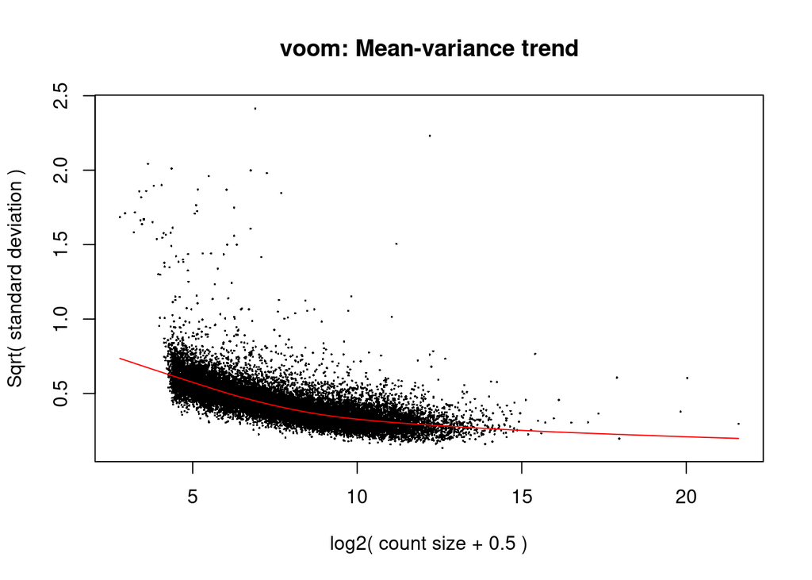

```r
bra_v <- voom(bra, plot = TRUE)
```

### Plot an MDS plot to see observe the samples (5%)

After `voom()`, `limma` allows us to visualize the relationship of our samples with dimensionality reduction (MDS) in which **the distance between samples roughly reflect the dissimilarity between them**. The sample names are generated from the metadata, and WT.3.1 means the first technical replicate of the third biological replicate of a wild-type sample.

Please describe your expectation of (1) how replicates should be like in an MDS plot (2) how different genotypes should be like in an MDS plot. Then, plot it with `plotMDS()` and describe what you see. Is your prediction consistent with what you see?

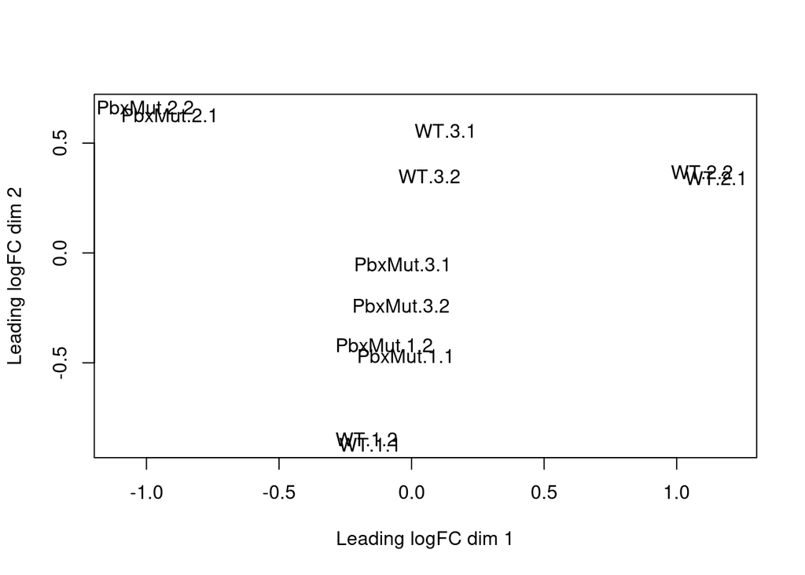

```r
plotMDS(bra_v)
```

Limma finds differential expression by fitting linear models with `lmFit()`, and then calculate the statistics with `eBayes()`. Please perform the analysis and plot an MA plot with `plotMA()`. What do you see? (5%)

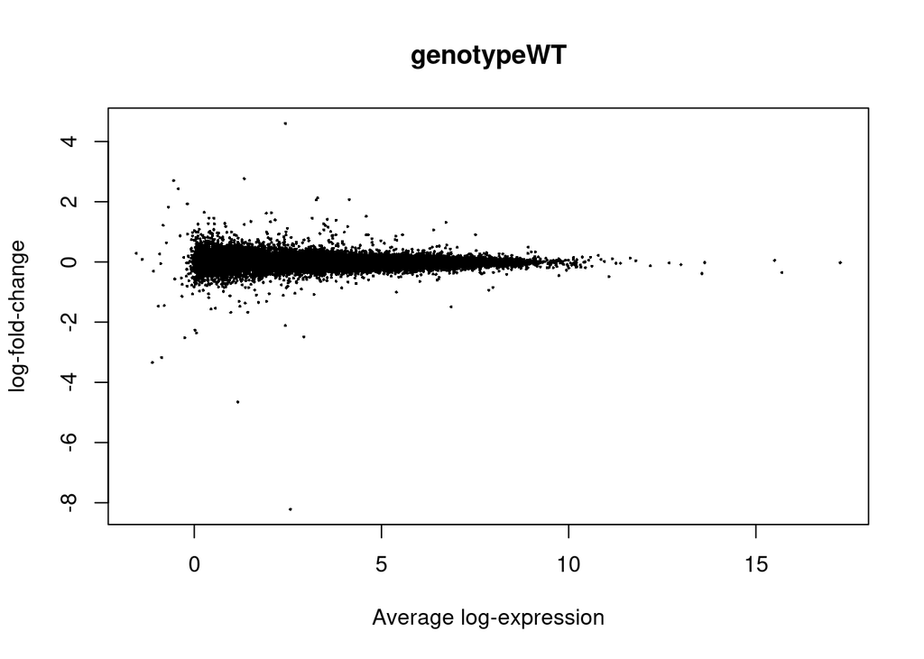

```r
bra_fit <- lmFit(bra_v, design_mtx)
bra_fit <- eBayes(bra_fit)

limma::plotMA(bra_fit)
```

### List top differentially expressed genes

After you are done with differential expression analysis, the list of differentially expressed genes can be retrieved with `topTable()`. Please save the differentially expressed genes that has an adjusted p-value < 0.05 as a csv file and submit it to NYU Classes (5%).

```r
# Get all DEGs
deg <- topTable(bra_fit, coef = "genotypeWT",
                number = nrow(bra))

# Filter DEGs by FDR < 0.05
deg <- filter(deg, adj.P.Val < 0.05)

write.csv(deg, "result/deg_fdr0.05.csv")

# coolmap(bra[row.names(deg), ])
```

## GSEA and GO

To better understand the function the differentially regulated genes served, we can perform enrichment analysis to see if functionally similar genes are over-represented in the differentially expressed genes.

### GSEA

We are going to use the hallmark gene set from MSigDB to perform gene set enrichment analysis. After loading the gene set containing `MSigDb/mouse_H_v5p2.rdata`, the first thing you’ll notice is that the gene set is documented in Entrez Gene ID (NCBI gene ID), so it’s great that we have converted our gene id earlier in the analysis.

Please load the hallmark gene set and perform GSEA, and take the top 10 enriched gene sets for up/down/mixed respectively. `romer()` takes your voom-processed object, and requires you to first convert ids to indices with `ids2indices()`.

Print the 3 tables in this Rmarkdown file (5% each).

```r
# Load mouse hallmark gene sets
# http://bioinf.wehi.edu.au/software/MSigDB/
load("MSigDb/mouse_H_v5p2.rdata")

c2t <- ids2indices(Mm.H, row.names(bra_v))

rr <- romer(bra_v, c2t, design = design_mtx, nrot = 1e4)
```

```r
romerUP <- topRomer(rr, n=10, alt = "up")
print(romerUP)
```

```
##                                    NGenes         Up      Down      Mixed
## HALLMARK_IL2_STAT5_SIGNALING          217 0.00489951 0.9952005 0.72092791
## HALLMARK_TNFA_SIGNALING_VIA_NFKB      201 0.00719928 0.9929007 0.12508749
## HALLMARK_ANDROGEN_RESPONSE            142 0.01049895 0.9896010 0.00089991
## HALLMARK_ANGIOGENESIS                  34 0.03859614 0.9615038 0.85411459
## HALLMARK_COAGULATION                  102 0.06309369 0.9370063 0.93080692
## HALLMARK_UV_RESPONSE_DN               224 0.06699330 0.9331067 0.36516348
## HALLMARK_TGF_BETA_SIGNALING            77 0.07339266 0.9267073 0.56894311
## HALLMARK_INFLAMMATORY_RESPONSE        156 0.12008799 0.8800120 0.35056494
## HALLMARK_INTERFERON_ALPHA_RESPONSE     76 0.12778722 0.8723128 0.93390661
## HALLMARK_COMPLEMENT                   197 0.18928107 0.8108189 0.47165283
```

```r
romerDOWN <- topRomer(rr, n = 10, alt = "down")
print(romerDOWN)
```

```
##                                          NGenes        Up       Down      Mixed
## HALLMARK_XENOBIOTIC_METABOLISM              194 0.9999000 0.00019998 0.72482752
## HALLMARK_OXIDATIVE_PHOSPHORYLATION          232 0.9998000 0.00029997 0.00529947
## HALLMARK_MYC_TARGETS_V2                      62 0.9995000 0.00059994 0.34216578
## HALLMARK_REACTIVE_OXIGEN_SPECIES_PATHWAY     56 0.9983002 0.00179982 0.00069993
## HALLMARK_ADIPOGENESIS                       244 0.9963004 0.00379962 0.22597740
## HALLMARK_GLYCOLYSIS                         227 0.9942006 0.00589941 0.00009999
## HALLMARK_DNA_REPAIR                         181 0.9788021 0.02129787 0.02189781
## HALLMARK_MTORC1_SIGNALING                   253 0.9768023 0.02329767 0.04069593
## HALLMARK_MYC_TARGETS_V1                     240 0.9616038 0.03849615 0.00529947
## HALLMARK_E2F_TARGETS                        247 0.9610039 0.03909609 0.24967503
```

```r
romerMIX <- topRomer(rr, n = 10, alt = "mixed")
print(romerMIX)
```

```
##                                          NGenes         Up       Down
## HALLMARK_GLYCOLYSIS                         227 0.99420058 0.00589941
## HALLMARK_REACTIVE_OXIGEN_SPECIES_PATHWAY     56 0.99830017 0.00179982
## HALLMARK_ANDROGEN_RESPONSE                  142 0.01049895 0.98960104
## HALLMARK_OXIDATIVE_PHOSPHORYLATION          232 0.99980002 0.00029997
## HALLMARK_MYC_TARGETS_V1                     240 0.96160384 0.03849615
## HALLMARK_APICAL_JUNCTION                    249 0.37026297 0.62983702
## HALLMARK_DNA_REPAIR                         181 0.97880212 0.02129787
## HALLMARK_P53_PATHWAY                        213 0.59214079 0.40795920
## HALLMARK_HYPOXIA                            214 0.74262574 0.25757424
## HALLMARK_SPERMATOGENESIS                    156 0.67113289 0.32896710
##                                               Mixed
## HALLMARK_GLYCOLYSIS                      0.00009999
## HALLMARK_REACTIVE_OXIGEN_SPECIES_PATHWAY 0.00069993
## HALLMARK_ANDROGEN_RESPONSE               0.00089991
## HALLMARK_OXIDATIVE_PHOSPHORYLATION       0.00529947
## HALLMARK_MYC_TARGETS_V1                  0.00529947
## HALLMARK_APICAL_JUNCTION                 0.02089791
## HALLMARK_DNA_REPAIR                      0.02189781
## HALLMARK_P53_PATHWAY                     0.02309769
## HALLMARK_HYPOXIA                         0.03599640
## HALLMARK_SPERMATOGENESIS                 0.03709629
```

### GO enrichment analysis

Another useful gene annotation is gene ontology. To perform GO term enrichment test, `limma` provides a function, `goana`. To use the function, you need `GO.db`, `org.Mm.eg.db`, and `BiasedUrn` for GO term information, so make sure they are installed from Bioconductor.

`goana()` takes the output of `eBayes()`, and to correct for gene abundance and length, you need to set `trend = TRUE`.

Perform GO enrichment analysis with an FDR threshold of 0.05, and print the top 10 enriched biological process terms (BP) for up-regulated and down-regulated genes with `topGO()` (7.5% each).

```r
gotest <- goana(bra_fit, coef = 1, species = "Mm", trend = TRUE, FDR = 0.05)
```

```r
gotest_bp_up <- topGO(gotest, ontolog = "BP", number = 10, sort = "Up")
print(gotest_bp_up)
```

```
##                                                   Term Ont     N    Up Down
## GO:0044237                  cellular metabolic process  BP  7364  7205    1
## GO:0006807         nitrogen compound metabolic process  BP  6780  6638    1
## GO:0043170             macromolecule metabolic process  BP  6561  6425    1
## GO:0044260    cellular macromolecule metabolic process  BP  5698  5587    1
## GO:0044238                   primary metabolic process  BP  7134  6977    1
## GO:0008150                          biological_process  BP 13126 12737    4
## GO:0008152                           metabolic process  BP  7930  7745    1
## GO:0071704         organic substance metabolic process  BP  7541  7367    1
## GO:0006996                      organelle organization  BP  3010  2963    0
## GO:0034645 cellular macromolecule biosynthetic process  BP  3426  3368    1
##                    P.Up    P.Down
## GO:0044237 7.960330e-15 0.9748347
## GO:0006807 1.636526e-14 0.9618919
## GO:0043170 3.573352e-14 0.9559709
## GO:0044260 8.102451e-14 0.9246341
## GO:0044238 2.251690e-13 0.9701595
## GO:0008150 5.538305e-13 0.9494612
## GO:0008152 8.630264e-13 0.9836133
## GO:0071704 2.245498e-12 0.9777837
## GO:0006996 1.470170e-10 1.0000000
## GO:0034645 1.709804e-10 0.7514518
```

```r
gotest_bp_down <- topGO(gotest, ontolog = "BP", number = 10, sort = "Down")
print(gotest_bp_down)
```

```
##                                                                                                                               Term
## GO:1901522 positive regulation of transcription from RNA polymerase II promoter involved in cellular response to chemical stimulus
## GO:0048384                                                                                retinoic acid receptor signaling pathway
## GO:0007218                                                                                          neuropeptide signaling pathway
## GO:0031641                                                                                               regulation of myelination
## GO:0032526                                                                                               response to retinoic acid
## GO:0042552                                                                                                             myelination
## GO:0008366                                                                                                       axon ensheathment
## GO:0007272                                                                                                 ensheathment of neurons
## GO:0030522                                                                                intracellular receptor signaling pathway
## GO:0033993                                                                                                       response to lipid
##            Ont   N  Up Down      P.Up      P.Down
## GO:1901522  BP  20  19    1 0.8606561 0.007043716
## GO:0048384  BP  25  23    1 0.9469437 0.008686258
## GO:0007218  BP  33  29    1 0.9916849 0.011044925
## GO:0031641  BP  44  41    1 0.9366542 0.015254594
## GO:0032526  BP  60  57    1 0.8614020 0.020948304
## GO:0042552  BP 118 113    1 0.7937418 0.040736807
## GO:0008366  BP 119 114    1 0.7866536 0.041042832
## GO:0007272  BP 119 114    1 0.7866536 0.041042832
## GO:0030522  BP 161 150    1 0.9914029 0.055152088
## GO:0033993  BP 446 423    1 0.9818945 0.146594275
```

### What do you learn from GSEA and GO (bonus 10%, total points capped at 100)

Checking the enriched terms and gene sets, what do you learn from it? Can you make an educated guess about what Pbx is doing in spinal motor neurons?